# In this Notebook, you will find the Module 3 Time Series Decomposition requirements for **Public** Construction Spending

1. Use pandas to import the data and complete your analysis.
2. Use Jupyter for your time series decomposition analysis.
3. Use markdown to document your analysis.
4. For each of the two data series:
   1. Compute the squared error for your model relative to the original data series for each month, and cumulatively as well.
   2. Compute a pandas column named R2X that shows the error of your model relative to the original data series, where X is replaced by either Public or Private for the respective analyses.
   3. Compute a pandas column named R2ErrorX that shows R2 relative to (divided by) the original data series.

```python
##import matplotlib and pandas
import matplotlib.pyplot as plt
import pandas as pd
import numpy as np
%matplotlib inline

##read files and drop unnecessary columns
dfTS = pd.read_csv('C:\\Users\\Cora\\Documents\\haleigh\\BUAD 5112\\CTBA\\M3\\ConstructionTimeSeriesDataV2.csv')
dfTS = dfTS.drop('Month', 1)
dfTS = dfTS.drop('Total Construction', 1)
dfTS = dfTS.drop('Private Construction', 1)
print(dfTS)
```

```
    Month-Year  Public Construction
0       Jan-02                14243
1       Feb-02                14113
2       Mar-02                14386
3       Apr-02                16221
4       May-02                18375
..         ...                  ...
141     Oct-13                25823
142     Nov-13                22741
143     Dec-13                19369
144     Jan-14                16834
145     Feb-14                16721

[146 rows x 2 columns]
```

### Raw Data Plot

The idea of plotting the raw data is to help determine how to best model going forward. With this graph you see the trend of each **cycle** and its nonlinearity and how I can start decomposing them.

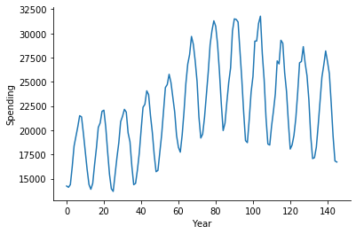

```python
##plot the Public Constructions raw data to understand its linearity
fig, ax = plt.subplots()
ax.plot(dfTS['Public Construction'], label='Public Construction')
ax.set_xlabel('Year')
ax.set_ylabel('Spending')
ax.spines['right'].set_visible(False)
ax.spines['top'].set_visible(False)
```

### Square Error and Moving Average

To begin analyzing the trend, I computed the **square error** and **moving average**. Squared Error helped me in picking an appropriate sized window for the moving average. 12 and 36 created a significanly higher Average Squared Error than 24 did. The moving average will help me see trends and offers a smoothed line to help deviate from seeing false spikes or pitfalls.

```
Average Squared Error per Month:  13456340.23072845
           Month-Year  Public Construction        MovAvg         sqErr
2003-01-31     Jan-03                14404  17892.625000  1.217050e+07
2003-02-28     Feb-03                13906  17877.875000  1.577579e+07
2003-03-31     Mar-03                14510  17891.062500  1.143158e+07
2003-04-30     Apr-03                16444  17933.000000  2.217121e+06
2003-05-31     May-03                18187  17959.875000  5.158577e+04
...               ...                  ...           ...           ...
2012-10-31     Oct-12                25632  23052.333333  6.654680e+06
2012-11-30     Nov-12                23148  23023.020833  1.561979e+04
2012-12-31     Dec-12                19396  22966.104167  1.274564e+07
2013-01-31     Jan-13                17074  22910.187500  3.406108e+07
2013-02-28     Feb-13                17171  22847.958333  3.222786e+07

[122 rows x 4 columns]
```

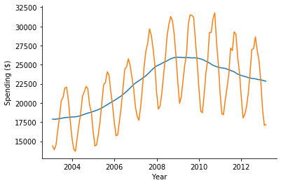

```python
##create square error variable
def sqErr(row):
    return (row['Public Construction'] - row['MovAvg'])**2

dfTS['MovAvg'] = np.NaN
dfTS['sqErr'] = np.NaN

##technical statement creating an index of the data frame to be datetime type
dfTS.index = pd.DatetimeIndex(freq='m', start=pd.Timestamp(year=2002, month=1, day=31), periods = len(dfTS['Public Construction']))

##tried a couple windows, 24 was the most appropriate number
window = 24
window = window - window % 2

for i in range(int(window/2), dfTS.shape[0]-int(window/2)):
    dfTS.loc[dfTS.index[i], 'MovAvg'] = (0.5*dfTS.iloc[i - int(window/2)]['Public Construction'] + dfTS.iloc[i - int(window/2)+1:i + int(window/2)]['Public Construction'].sum() + 0.5 *dfTS.iloc[i + int(window/2)]['Public Construction'])/float(window)

##compute squared error
dfTS['sqErr'] = (dfTS['Public Construction'] - dfTS['MovAvg']) **2

##drop rows we cannot use
dfTS.dropna(how='any', inplace=True)

##plot data
fig, ax = plt.subplots()
ax.plot(dfTS['MovAvg'], label='Moving Average')
ax.plot(dfTS['Public Construction'], label = 'Public Construction')
ax.set_xlabel('Year')
ax.set_ylabel('Spending ($)')
ax.spines['right'].set_visible(False)
ax.spines['top'].set_visible(False)
print('Average Squared Error per Month: ', sum(dfTS['sqErr'])/len(dfTS))
print(dfTS)
```

### Residual and Residual Error (R1Public/R1ErrorPublic)

Next, I computed the first reaminder **residual** for Public Construction spending and each points percentage of spending relative to the moving average. This will determine what is left to explain in my analysis.

```python
##compute remainder and error data, and print
dfTS['R1Public'] = dfTS['Public Construction'] - dfTS['MovAvg']
dfTS['R1ErrorPublic'] = abs((dfTS['Public Construction'] - dfTS['R1Public'])/dfTS['Public Construction'])
dfTS.style.format({
    'MovAvg': '{:.1f}'.format,
    'sqErr': '{:,.1f}'.format,
    'R1Public': '{:,.1f}'.format,
    'R1ErrorPublic': '{:,.3f}'.format
})
```

|  | Month-Year | Public Construction | MovAvg | sqErr | R1Public | R1ErrorPublic |
| --- | --- | --- | --- | --- | --- | --- |
| 2003-01-31 00:00:00 | Jan-03 | 14404 | 17892.6 | 12,170,504.4 | -3,488.6 | 1.242 |
| 2003-02-28 00:00:00 | Feb-03 | 13906 | 17877.9 | 15,775,791.0 | -3,971.9 | 1.286 |
| 2003-03-31 00:00:00 | Mar-03 | 14510 | 17891.1 | 11,431,583.6 | -3,381.1 | 1.233 |
| 2003-04-30 00:00:00 | Apr-03 | 16444 | 17933.0 | 2,217,121.0 | -1,489.0 | 1.091 |
| 2003-05-31 00:00:00 | May-03 | 18187 | 17959.9 | 51,585.8 | 227.1 | 0.988 |
| 2003-06-30 00:00:00 | Jun-03 | 20301 | 17998.3 | 5,302,273.8 | 2,302.7 | 0.887 |
| 2003-07-31 00:00:00 | Jul-03 | 20755 | 18052.2 | 7,304,970.2 | 2,702.8 | 0.870 |
| 2003-08-31 00:00:00 | Aug-03 | 21957 | 18088.3 | 14,966,743.0 | 3,868.7 | 0.824 |
| 2003-09-30 00:00:00 | Sep-03 | 22075 | 18112.2 | 15,703,552.7 | 3,962.8 | 0.820 |
| 2003-10-31 00:00:00 | Oct-03 | 20321 | 18123.3 | 4,830,013.5 | 2,197.7 | 0.892 |
| 2003-11-30 00:00:00 | Nov-03 | 17801 | 18144.9 | 118,264.3 | -343.9 | 1.019 |
| 2003-12-31 00:00:00 | Dec-03 | 15466 | 18172.7 | 7,326,044.4 | -2,706.7 | 1.175 |
| 2004-01-31 00:00:00 | Jan-04 | 13959 | 18179.1 | 17,809,455.0 | -4,220.1 | 1.302 |
| 2004-02-29 00:00:00 | Feb-04 | 13689 | 18191.4 | 20,271,193.0 | -4,502.4 | 1.329 |
| 2004-03-31 00:00:00 | Mar-04 | 15443 | 18233.5 | 7,786,657.7 | -2,790.5 | 1.181 |
| 2004-04-30 00:00:00 | Apr-04 | 17177 | 18288.1 | 1,234,506.2 | -1,111.1 | 1.065 |
| 2004-05-31 00:00:00 | May-04 | 18709 | 18353.1 | 126,647.0 | 355.9 | 0.981 |
| 2004-06-30 00:00:00 | Jun-04 | 20893 | 18436.1 | 6,036,234.8 | 2,456.9 | 0.882 |
| 2004-07-31 00:00:00 | Jul-04 | 21444 | 18519.4 | 8,553,187.7 | 2,924.6 | 0.864 |
| 2004-08-31 00:00:00 | Aug-04 | 22164 | 18603.7 | 12,675,825.1 | 3,560.3 | 0.839 |
| 2004-09-30 00:00:00 | Sep-04 | 21876 | 18681.4 | 10,205,362.7 | 3,194.6 | 0.854 |
| 2004-10-31 00:00:00 | Oct-04 | 19726 | 18739.9 | 972,360.3 | 986.1 | 0.950 |
| 2004-11-30 00:00:00 | Nov-04 | 18809 | 18806.0 | 9.0 | 3.0 | 1.000 |
| 2004-12-31 00:00:00 | Dec-04 | 16295 | 18889.1 | 6,729,160.3 | -2,594.1 | 1.159 |
| 2005-01-31 00:00:00 | Jan-05 | 14380 | 18967.7 | 21,046,685.4 | -4,587.7 | 1.319 |
| 2005-02-28 00:00:00 | Feb-05 | 14517 | 19049.5 | 20,543,556.2 | -4,532.5 | 1.312 |
| 2005-03-31 00:00:00 | Mar-05 | 15920 | 19141.5 | 10,378,196.5 | -3,221.5 | 1.202 |
| 2005-04-30 00:00:00 | Apr-05 | 17656 | 19237.7 | 2,501,735.3 | -1,581.7 | 1.090 |
| 2005-05-31 00:00:00 | May-05 | 20097 | 19355.7 | 549,513.3 | 741.3 | 0.963 |
| 2005-06-30 00:00:00 | Jun-05 | 22375 | 19497.7 | 8,278,807.3 | 2,877.3 | 0.871 |

[output cut: 92 more lines]

### Plotting R1Public

While plotting the remainder (R1Public), you can see there is still irregularity I have yet to define. The average is around -60 as the trend line seems to be horizontal at that point.

```
Average Residual:  -61.733777322404364
```

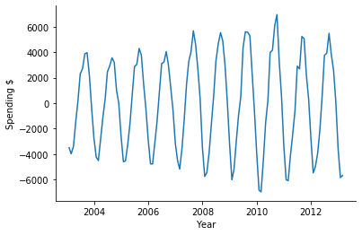

```python
##plot remainder data computed above
fig, ax = plt.subplots()
ax.plot(dfTS['R1Public'])
ax.set_xlabel('Year')
ax.set_ylabel('Spending $')
ax.spines['right'].set_visible(False)
ax.spines['top'].set_visible(False)
print('Average Residual: ', sum(dfTS['R1Public'])/len(dfTS))
```

### Autocorrelation

```python
##compute autocorrelation relative to each 24 month time period
maxCorr = 0.0
perio = np.NaN
for i in range(1, 25):
    corr = dfTS['R1Public'].autocorr(lag=i)
    print('Correlation, lag ',i,'   ', corr)
    if corr > maxCorr:
        maxCorr = corr
        period = i
print('period = ',period,'    Maximum Correlation = ',maxCorr)
```

```
Correlation, lag  1     0.8491719686828484
Correlation, lag  2     0.48164018705362094
Correlation, lag  3     -0.01184002333988436
Correlation, lag  4     -0.4987016188834364
Correlation, lag  5     -0.8362285995426119
Correlation, lag  6     -0.9584853417076531
Correlation, lag  7     -0.8410219068050431
Correlation, lag  8     -0.4973341764617763
Correlation, lag  9     -0.002505205348866353
Correlation, lag  10     0.4811044005440983
Correlation, lag  11     0.8398692171347962
Correlation, lag  12     0.9807625496082436
Correlation, lag  13     0.8372362751457391
Correlation, lag  14     0.4802838606708958
Correlation, lag  15     -0.010102456354731356
Correlation, lag  16     -0.4907689931289588
Correlation, lag  17     -0.8244225050556092
Correlation, lag  18     -0.9473385681101442
Correlation, lag  19     -0.8313211744978629
Correlation, lag  20     -0.4931982696422309
Correlation, lag  21     -0.009194028259920582
Correlation, lag  22     0.46816047357468393
Correlation, lag  23     0.831227091106744
Correlation, lag  24     0.9724598010815724
period =  12     Maximum Correlation =  0.9807625496082436
```

### Averages for all 24 Points in Cycle

Computing the average cycle within all available cycles in the data helped examine how well the averages fit in the data. with the plot below, you can see the average moves consistently with each of the other cycles

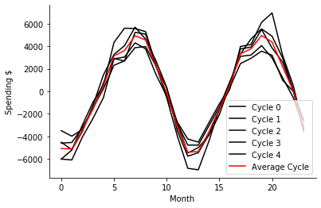

```python
##compute and plot averages and cycle data
period = 24
cycleLen = period
numCycles = int(len(dfTS)/cycleLen + 0.5)
cycles = [dfTS.iloc[range(i*period, min((i+1)*period, len(dfTS)))]['R1Public'] for i in range(numCycles)]
ptsInCycles = [dfTS.iloc[range(i, len(dfTS['R1Public']), period)]['R1Public'].tolist() for i in range(period)]
avg = [sum(pts)/len(pts) for pts in ptsInCycles]

fig, ax = plt.subplots()
for i in range(len(cycles)):
    ax.plot(cycles[i].values, label = 'Cycle '+str(i), c='k')
ax.plot(avg,label = 'Average Cycle', c='r')
ax.set_xlabel('Month')
ax.set_ylabel('Spending $')
ax.spines['right'].set_visible(False)
ax.spines['top'].set_visible(False)
ax.legend()
```

### Cyclicality

To determine how the averages computed above fared with the remainder values within each cycles data, I computed the cyclicality. This revealed a very good following of (C) to (R1Public).

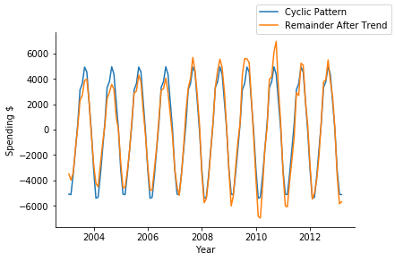

```python
#compute Cyclicality data and plot its consistency with remainder data
cycleLen = period
numCycles = int(len(dfTS)/cycleLen + 0.5)
dfTS['C'] = np.NaN
for i in range(len(dfTS)):
    dfTS.loc[dfTS.index[i], 'C'] = avg[i % cycleLen]

fig, ax = plt.subplots()
ax.plot(dfTS['C'], label = 'Cyclic Pattern')
ax.plot(dfTS['R1Public'],label='Remainder After Trend')
ax.set_xlabel('Year')
ax.set_ylabel('Spending $')
ax.spines['right'].set_visible(False)
ax.spines['top'].set_visible(False)
fig.legend()
```

### Second Remainder (R2Public)

To find the remainder after the 2 components (R1Public & C), I subtracted the two. Also having to find the error of this remainder (R2ErrorPublic), I used a similar equation as R1ErrorPublic by switching the variable to include this new remainder. Fit being the sum of the moving average and the cyclicality, I used this to plot it against the original data for Public Construction spending.

```
Average Error:  0.025896516156726432
           Month-Year  Public Construction        MovAvg     R1Public  \
2003-01-31     Jan-03                14404  17892.625000 -3488.625000
2003-02-28     Feb-03                13906  17877.875000 -3971.875000
2003-03-31     Mar-03                14510  17891.062500 -3381.062500
2003-04-30     Apr-03                16444  17933.000000 -1489.000000
2003-05-31     May-03                18187  17959.875000   227.125000
...               ...                  ...           ...          ...
2012-10-31     Oct-12                25632  23052.333333  2579.666667
2012-11-30     Nov-12                23148  23023.020833   124.979167
2012-12-31     Dec-12                19396  22966.104167 -3570.104167
2013-01-31     Jan-13                17074  22910.187500 -5836.187500
2013-02-28     Feb-13                17171  22847.958333 -5676.958333

            R1ErrorPublic            C     R2Public  R2ErrorPublic  \
2003-01-31       1.242198 -5072.795139  1584.170139       0.109981
2003-02-28       1.285623 -5106.680556  1134.805556       0.081605
2003-03-31       1.233016 -3443.304167    62.241667       0.004290
2003-04-30       1.090550 -1549.966667    60.966667       0.003708
2003-05-31       0.987512   479.229167  -252.104167       0.013862
...                   ...          ...          ...            ...
2012-10-31       0.899358  2180.566667   399.100000       0.015570
2012-11-30       0.994601    50.458333    74.520833       0.003219
2012-12-31       1.184064 -3172.987500  -397.116667       0.020474
2013-01-31       1.341817 -5072.795139  -763.392361       0.044711
2013-02-28       1.330613 -5106.680556  -570.277778       0.033212

                     fit
2003-01-31  12819.829861
2003-02-28  12771.194444
2003-03-31  14447.758333
2003-04-30  16383.033333
2003-05-31  18439.104167
...                  ...
2012-10-31  25232.900000
2012-11-30  23073.479167
2012-12-31  19793.116667
2013-01-31  17837.392361
2013-02-28  17741.277778

[122 rows x 9 columns]
```

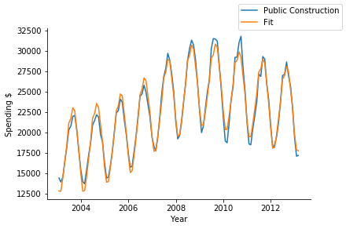

```python
##compute and plot remainder after first remainder (R1) & cyclical data
dfTS['R2Public'] = dfTS['R1Public'] - dfTS['C']
dfTS['R2ErrorPublic'] = abs(dfTS['R2Public']/dfTS['Public Construction'])
dfTS['fit'] = dfTS['MovAvg'] + dfTS['C']
dfTS.drop(['sqErr'], axis=1, inplace = True)
print('Average Error: ', sum(dfTS['R2ErrorPublic'])/len(dfTS))
print(dfTS)

fig, ax = plt.subplots()
ax.plot(dfTS['Public Construction'], label = 'Public Construction')
ax.plot(dfTS['fit'], label = 'Fit')
ax.set_xlabel('Year')
ax.set_ylabel('Spending $')
ax.spines['right'].set_visible(False)
ax.spines['top'].set_visible(False)
fig.legend()
```

```
Correlation, lag  1     0.685535570264353
Correlation, lag  2     0.4012453875720723
Correlation, lag  3     0.1427512215256592
Correlation, lag  4     -0.21838819800894269
Correlation, lag  5     -0.43236129870933837
Correlation, lag  6     -0.5807112217013529
Correlation, lag  7     -0.6540558835578975
Correlation, lag  8     -0.487208353850567
Correlation, lag  9     -0.19656649799238074
Correlation, lag  10     -0.0015271611553541984
Correlation, lag  11     0.31717019472507973
Correlation, lag  12     0.49357301436964457
Correlation, lag  13     0.44896826318845745
Correlation, lag  14     0.4769894550626929
Correlation, lag  15     0.2505959556608195
Correlation, lag  16     0.029781321823427066
Correlation, lag  17     -0.11758118912437639
Correlation, lag  18     -0.27538220679629455
Correlation, lag  19     -0.3504425146326273
Correlation, lag  20     -0.2795948769051118
Correlation, lag  21     -0.17893510557537282
Correlation, lag  22     -0.03382176191382436
Correlation, lag  23     0.20304809374101285
Correlation, lag  24     0.2083935075014699
period =  1     Maximum Correlation =  0.685535570264353
```

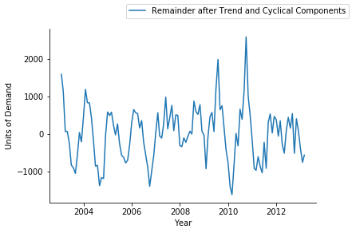

```python
##compute and plot correlation of second remainder and original data
fig, ax = plt.subplots()
ax.plot(dfTS['R2Public'], label = 'Remainder after Trend and Cyclical Components')
ax.set_xlabel('Year')
ax.set_ylabel('Spending ($)')
ax.set_ylabel('Units of Demand')
ax.spines['right'].set_visible(False)
ax.spines['top'].set_visible(False)
fig.legend()
maxCorr = 0.0
period = np.NaN
for i in range(1, 25):
    corr = dfTS['R2Public'].autocorr(lag = i)
    print('Correlation, lag ',i,'   ', corr)
    if corr > maxCorr:
        maxCorr = corr
        period = i
print('period = ',period,'    Maximum Correlation = ',maxCorr)
```

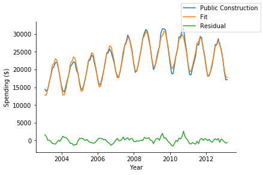

```python
fig, ax = plt.subplots()
ax.plot(dfTS['Public Construction'], label = 'Public Construction')
ax.plot(dfTS['fit'], label = 'Fit')
ax.plot(dfTS['R2Public'], label = 'Residual')
ax.set_xlabel('Year')
ax.set_ylabel('Spending ($)')
ax.spines['right'].set_visible(False)
ax.spines['top'].set_visible(False)
fig.legend()
```